# 3.1: Linear Regression for Prediction

Sajini Arumugam

6/29/2020

## **Linear Regression for Prediction**

The predict() function takes a fitted object from functions such as lm() or glm() and a data frame with the new predictors for which to predict.

predict() is a generic function in R that calls other functions depending on what kind of object it receives. To learn about the specifics, you can read the help files using code like this:

```
y_hat <- predict(fit, test_set)
```

### **Comprehension Check: Linear Regression**

#### *Question 1*

Create a data set using the following code:

```r
library(tidyverse)
library(dslabs)
library(dplyr)
library(caret)
set.seed(1) # set.seed(1, sample.kind="Rounding") if using R 3.6 or later
n <- 100
Sigma <- 9*matrix(c(1.0, 0.5, 0.5, 1.0), 2, 2)
dat <- MASS::mvrnorm(n = 100, c(69, 69), Sigma) %>%
      data.frame() %>% setNames(c("x", "y"))
```

We will build 100 linear models using the data above and calculate the mean and standard deviation of the combined models. First, set the seed to 1 again (make sure to use sample.kind=“Rounding” if your R is version 3.6 or later). Then, within a replicate() loop, (1) partition the dataset into test and training sets with p=0.5 and using dat$y to generate your indices, (2) train a linear model predicting y from x, (3) generate predictions on the test set, and (4) calculate the RMSE of that model. Then, report the mean and standard deviation (SD) of the RMSEs from all 100 models.

Report all answers to at least 3 decimal places.

```r
set.seed(1)    # if R 3.6 or later, set.seed(1, sample.kind="Rounding")
rmse <- replicate(100, {
    test_index <- createDataPartition(dat$y, times = 1, p = 0.5, list = FALSE)
    train_set <- dat %>% slice(-test_index)
    test_set <- dat %>% slice(test_index)
    fit <- lm(y ~ x, data = train_set)
    y_hat <- predict(fit, newdata = test_set)
    sqrt(mean((y_hat-test_set$y)^2))
})

mean(rmse)
```

```
## [1] 2.485441
```

```r
sd(rmse)
```

```
## [1] 0.1316324
```

#### *Question 2*

Now we will repeat the exercise above but using larger datasets. Write a function that takes a size n, then (1) builds a dataset using the code provided at the top of Q1 but with n observations instead of 100 and without the set.seed(1), (2) runs the replicate() loop that you wrote to answer Q1, which builds 100 linear models and returns a vector of RMSEs, and (3) calculates the mean and standard deviation of the 100 RMSEs.

Set the seed to 1 (if using R 3.6 or later, use the argument sample.kind=“Rounding”) and then use sapply() or map() to apply your new function to n <- c(100, 500, 1000, 5000, 10000).

You only need to set the seed once before running your function; do not set a seed within your function. Also be sure to use sapply() or map() as you will get different answers running the simulations individually due to setting the seed.

```r
set.seed(1, sample.kind="Rounding")
n <- c(100, 500, 1000, 5000, 10000)
res <- sapply(n, function(n){
    Sigma <- 9*matrix(c(1.0, 0.5, 0.5, 1.0), 2, 2)
    dat <- MASS::mvrnorm(n, c(69, 69), Sigma) %>%
        data.frame() %>% setNames(c("x", "y"))
    rmse <- replicate(100, {
        test_index <- createDataPartition(dat$y, times = 1, p = 0.5, list = FALSE)
        train_set <- dat %>% slice(-test_index)
        test_set <- dat %>% slice(test_index)
        fit <- lm(y ~ x, data = train_set)
        y_hat <- predict(fit, newdata = test_set)
        sqrt(mean((y_hat-test_set$y)^2))
    })
    c(avg = mean(rmse), sd = sd(rmse))
})

res
```

```
##          [,1]       [,2]       [,3]       [,4]       [,5]
## avg 2.4977540 2.72095125 2.55554451 2.62482800 2.61844227
## sd  0.1180821 0.08002108 0.04560258 0.02309673 0.01689205
```

#### *Question 3*

What happens to the RMSE as the size of the dataset becomes larger?

On average, the RMSE does not change much as n gets larger, but the variability of the RMSE decreases. **  
Because of the law of large numbers the RMSE decreases; more data means more precise estimates.  
n = 10000 is not sufficiently large. To see a decrease in the RMSE we would need to make it larger.  
The RMSE is not a random variable.

#### *Question 4*

Now repeat the exercise from Q1, this time making the correlation between x and y larger, as in the following code:

```r
set.seed(1, sample.kind = "Rounding")
n <- 100
Sigma <- 9*matrix(c(1.0, 0.95, 0.95, 1.0), 2, 2)
dat <- MASS::mvrnorm(n = 100, c(69, 69), Sigma) %>%
    data.frame() %>% setNames(c("x", "y"))
```

```r
rmse <- replicate(100, {
    test_index <- createDataPartition(dat$y, times = 1, p = 0.5, list = FALSE)
    train_set <- dat %>% slice(-test_index)
    test_set <- dat %>% slice(test_index)
    fit <- lm(y ~ x, data = train_set)
    y_hat <- predict(fit, newdata = test_set)
    sqrt(mean((y_hat-test_set$y)^2))
})

mean(rmse)
```

```
## [1] 0.9167387
```

```r
sd(rmse)
```

```
## [1] 0.05226268
```

#### *Question 5*

Which of the following best explains why the RMSE in question 4 is so much lower than the RMSE in question 1?

- It is just luck. If we do it again, it will be larger.
- The central limit theorem tells us that the RMSE is normal.
- When we increase the correlation between x and y, x has more predictive power and thus provides a better estimate of y. **
- These are both examples of regression so the RMSE has to be the same.

#### *Question 6*

Create a data set using the following code.

```r
set.seed(1)
Sigma <- matrix(c(1.0, 0.75, 0.75, 0.75, 1.0, 0.25, 0.75, 0.25, 1.0), 3, 3)
dat <- MASS::mvrnorm(n = 100, c(0, 0, 0), Sigma) %>%
    data.frame() %>% setNames(c("y", "x_1", "x_2"))
```

Note that y is correlated with both x_1 and x_2 but the two predictors are independent of each other, as seen by cor(dat).

Set the seed to 1, then use the caret package to partition into a test and training set of equal size. Compare the RMSE when using just x_1, just x_2 and both x_1 and x_2. Train a single linear model for each (not 100 like in the previous questions).

Which of the three models performs the best (has the lowest RMSE)?

```r
set.seed(1)
test_index <- createDataPartition(dat$y, times = 1, p = 0.5, list = FALSE)
train_set <- dat %>% slice(-test_index)
test_set <- dat %>% slice(test_index)

fit <- lm(y ~ x_1, data = train_set)
y_hat <- predict(fit, newdata = test_set)
sqrt(mean((y_hat-test_set$y)^2))
```

```
## [1] 0.600666
```

```r
fit <- lm(y ~ x_2, data = train_set)
y_hat <- predict(fit, newdata = test_set)
sqrt(mean((y_hat-test_set$y)^2))
```

```
## [1] 0.630699
```

```r
fit <- lm(y ~ x_1 + x_2, data = train_set)
y_hat <- predict(fit, newdata = test_set)
sqrt(mean((y_hat-test_set$y)^2))
```

```
## [1] 0.3070962
```

- x_1 & x_2

#### *Question 7*

Report the lowest RMSE of the three models tested in Q6. 0.3070962

#### *Question 8*

Repeat the exercise from Q6 but now create an example in which x_1 and x_2 are highly correlated.

```r
set.seed(1)
Sigma <- matrix(c(1.0, 0.75, 0.75, 0.75, 1.0, 0.95, 0.75, 0.95, 1.0), 3, 3)
dat <- MASS::mvrnorm(n = 100, c(0, 0, 0), Sigma) %>%
    data.frame() %>% setNames(c("y", "x_1", "x_2"))
```

Set the seed to 1, then use the caret package to partition into a test and training set of equal size. Compare the RMSE when using just x_1, just x_2, and both x_1 and x_2.

Compare the results from Q6 and Q8. What can you conclude?

Unless we include all predictors we have no predictive power.  
Adding extra predictors improves RMSE regardless of whether the added predictors are correlated with other predictors or not.  
Adding extra predictors results in over fitting.  
Adding extra predictors can improve RMSE substantially, but not when the added predictors are highly correlated with other predictors. **

```r
set.seed(1)
test_index <- createDataPartition(dat$y, times = 1, p = 0.5, list = FALSE)
train_set <- dat %>% slice(-test_index)
test_set <- dat %>% slice(test_index)

fit <- lm(y ~ x_1, data = train_set)
y_hat <- predict(fit, newdata = test_set)
sqrt(mean((y_hat-test_set$y)^2))
```

```
## [1] 0.6592608
```

```r
fit <- lm(y ~ x_2, data = train_set)
y_hat <- predict(fit, newdata = test_set)
sqrt(mean((y_hat-test_set$y)^2))
```

```
## [1] 0.640081
```

```r
fit <- lm(y ~ x_1 + x_2, data = train_set)
y_hat <- predict(fit, newdata = test_set)
sqrt(mean((y_hat-test_set$y)^2))
```

```
## [1] 0.6597865
```

## **Comprehension Check: Logistic Regression**

#### *Question 1*

Define a dataset using the following code:

```r
set.seed(2, sample.kind="Rounding")
make_data <- function(n = 1000, p = 0.5,
                mu_0 = 0, mu_1 = 2,
                sigma_0 = 1,  sigma_1 = 1){

y <- rbinom(n, 1, p)
f_0 <- rnorm(n, mu_0, sigma_0)
f_1 <- rnorm(n, mu_1, sigma_1)
x <- ifelse(y == 1, f_1, f_0)

test_index <- createDataPartition(y, times = 1, p = 0.5, list = FALSE)

list(train = data.frame(x = x, y = as.factor(y)) %>% slice(-test_index),
    test = data.frame(x = x, y = as.factor(y)) %>% slice(test_index))
}
dat <- make_data()
```

Note that we have defined a variable x that is predictive of a binary outcome y: dat$train %>% ggplot(aes(x, color = y)) + geom_density().

Set the seed to 1, then use the make_data() function defined above to generate 25 different datasets with mu_1 <- seq(0, 3, len=25). Perform logistic regression on each of the 25 different datasets (predict 1 if p>0.5) and plot accuracy (res in the figures) vs mu_1 (delta in the figures).”

Which is the correct plot?

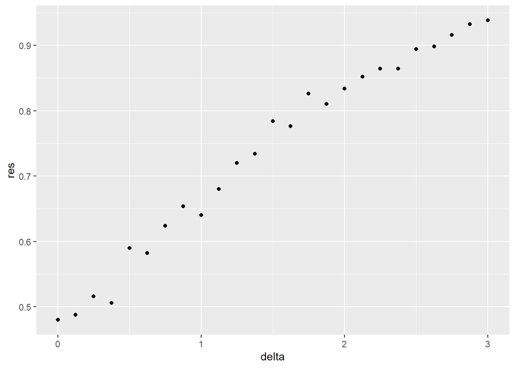

```r
delta <- seq(0, 3, len=25)
res <- sapply(delta, function(d){
  dat <-make_data(mu_1 = d)
  fit_glm <- dat$train%>% glm(y~x, family = "binomial", data = .)
  y_hat_glm <- ifelse(predict(fit_glm, dat$test)>0.5,1,0) %>% factor(levels = c(0,1))
  mean(y_hat_glm == dat$test$y)
})
qplot(delta,res)
```